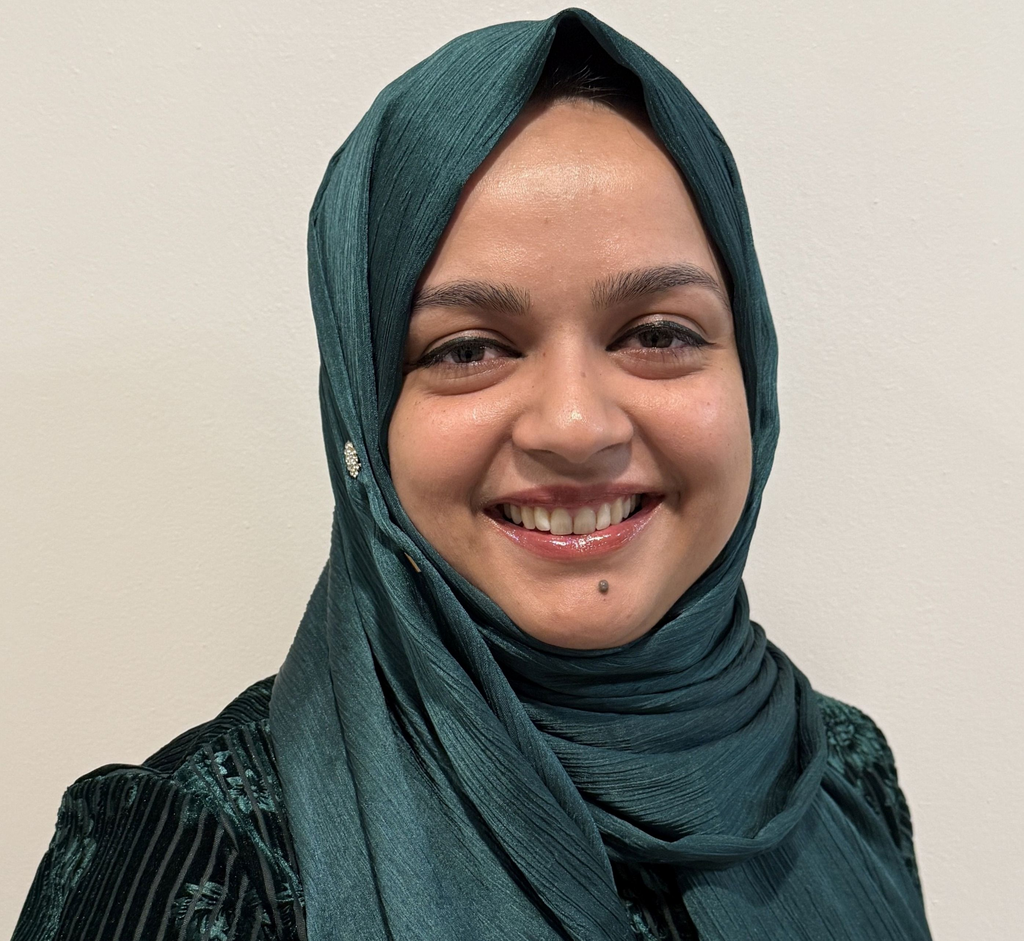

# Nusrat Jabin

## Bio

I am a PhD student in the **[Department of Population, Family, and Reproductive Health](https://publichealth.jhu.edu/departments/population-family-and-reproductive-health/people/students/phd-students)**, at the Johns Hopkins Bloomberg School of Public Health. My research focuses on maternal and child health, with particular interests in nutrition, epigenetic aging, and the developmental origins of health and disease (DOHaD). I have experience working with international research consortia and large-scale cohort studies, including projects on nutrition and epigenetic aging acceleration, gestational weight gain, indoor air pollution, and global pandemic preparedness.  
My long-term goal is to bridge research and policy by designing and analyzing studies that inform interventions and strategies to improve women’s health worldwide.

## Education

| **Johns Hopkins Bloomberg School of Public Health** |  | 2024 - present |
| --- | --- | --- |
| PhD in Population, Family, and Reproductive Health |  | 📍Baltimore, USA |
| **University of Oxford** |  | 2019 - 2020 |
| MS in International Health and Tropical Medicine |  | 📍Oxfordshire, UK |
| **Scineces Po** |  | 2013 - 2014 |
| Exchange Program |  | 📍Reims, France |
| **Asian University for Women** |  | 2010 - 2015 |
| BS in Public Health |  | 📍Chattagram, Bangladesh |

## Research experience

[output not shown]

## Selected Publications

[output not shown]

## In the Press

[output not shown]

## Conferences

| **APHA 2025 Annual Meeting, Washington D.C.** | November 2025 |
| --- | --- |
| [ ] Presented research titled **“Adequate maternal plasma folate levels are associated with deceleration of epigenetic aging: insights from Boston birth cohort”**. | 📍US |
| **DOHaD World Congress 2022, Vancouver.** | August 2022 |
| [ ] Presented research titled **“The Association between gestational weight gain and perinatal outcomes: The INTERBIO-21st Study”**. | 📍Canada |
| Presented a talk in the webinar titled **“What have we learned from funding COVID-19 research across the globe?”**. | November 2021 |
| **Bangladesh-Netherlands Conference, Hope XXL, Duive** | May 2016 |
| [ ] Presented a talk titled **“Warning of Paralyzed Bangladesh”**. | 📍Netherlands |
| **6th Regional Public Health Conference, Dhaka,** | December 2015 |
| [ ] Presented a research project titled **“Fistula: An Overlooked yet Preventable, Treatable Problem”**. | 📍Bangladesh |

## Achievements

| **[Chevening Scholarship](https://www.fenews.co.uk/skills/uk-governments-prestigious-chevening-scholarships-applications-for-2020-21-now-open-in-bangladesh/)** | 2019 - 2020 |
| --- | --- |
| 🏅 Scholarship | 📍UK |
| **[French Government Scholarship](https://bd.ambafrance.org/Nusrat-Jabin-studied-at-the)** | 2013 - 2014 |
| 🏅 Scholarship | 📍France |

## Interests and Hobbies

I love painting 🎨 cooking and eating traditional foods 🙂 🥘️ spending time in the nature 🌲🌲🌲 and reading about different cultures 📕 / 📗 / 📘 .

Please refer to my CV for more details about my education, past research and teaching experience, courses, publications and ongoing projects. In case of questions or queries, feel free to contact me in any of my social media.

[figure not shown]